# Homework 3

## Question 3

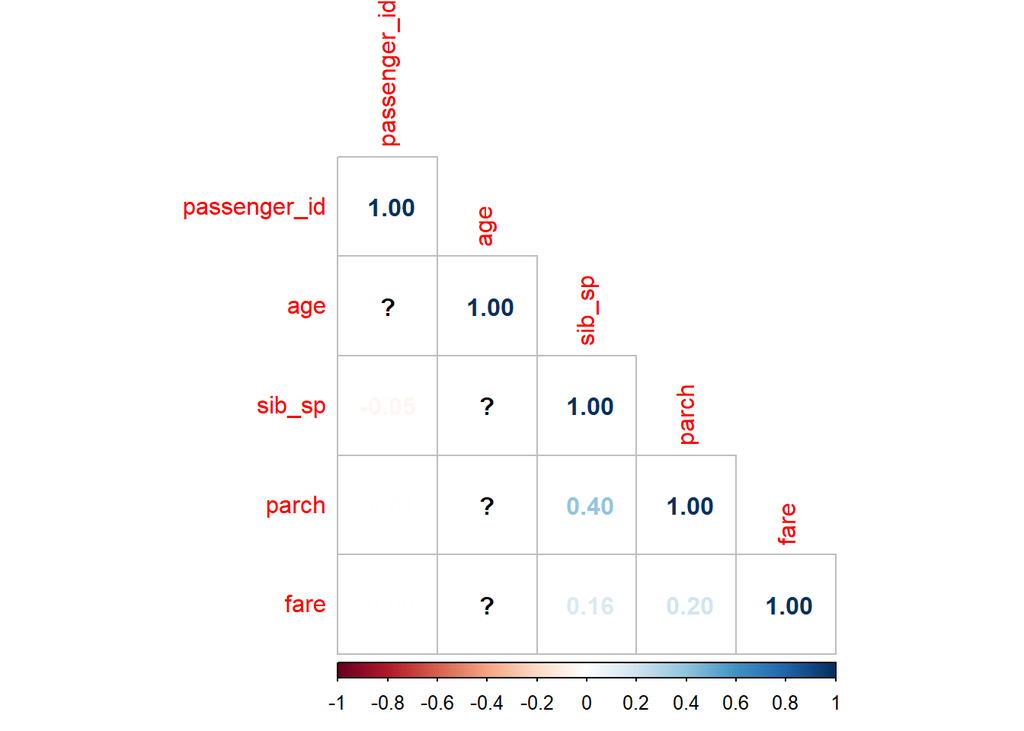

```r
titanic_train %>%
  select(is.numeric) %>%
  cor() %>%
  corrplot(type = 'lower', diag = TRUE,
           method = 'number')
```

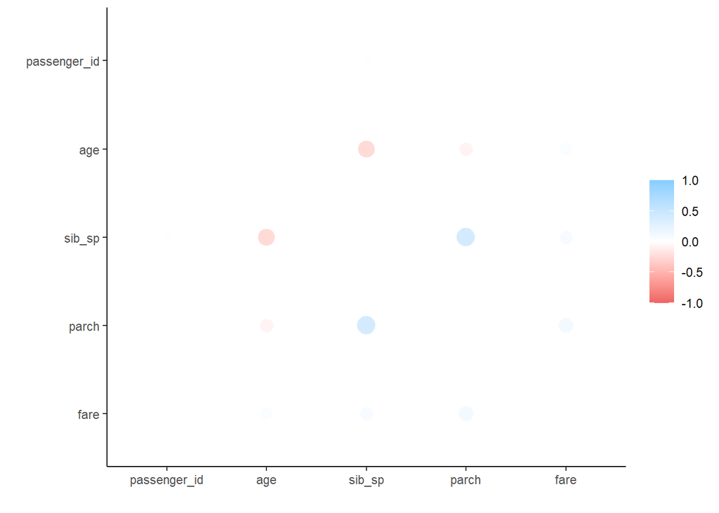

```r
cor_titanic_train <- titanic_train %>%
  select(is.numeric) %>%
  correlate()
rplot(cor_titanic_train)
```

```r
titanic_train %>%
  summarise(mean(age))
```

```
##   mean(age)
## 1        NA
```

Age is negatively correlated with the number of siblings / spouses aboard the Titanic.

The number of of siblings / spouses aboard the Titanic is positively correlated with the number of parents / children aboard the Titanic.

Age is also slightly negatively correlated with the number of parents / children aboard the Titanic.

The number of parents / children aboard the Titanic is also slightly positively correlated with the Passenger fare.

## Question 4

```r
titanic_recipe <- recipe(survived ~ pclass + sex + age + sib_sp + parch + fare, data = titanic_train) %>%
  step_impute_linear(age, impute_with = imp_vars(pclass, sex, sib_sp, parch, fare)) %>%
  step_dummy(all_nominal_predictors()) %>%
  step_interact(terms = ~ starts_with("sex"):fare) %>%
  step_interact(terms = ~ age:fare)


titanic_recipe
```

```
## Recipe
##
## Inputs:
##
##       role #variables
##    outcome          1
##  predictor          6
##
## Operations:
##
## Linear regression imputation for age
## Dummy variables from all_nominal_predictors()
## Interactions with starts_with("sex"):fare
## Interactions with age:fare
```

```r
prep(titanic_recipe) %>%
  bake(new_data = titanic_train) %>%
  head() %>%
  kable() %>%
  kable_styling(full_width = F) %>%
  scroll_box(width = "100%", height = "200px")
```

| age | sib_sp | parch | fare | survived | pclass_X2 | pclass_X3 | sex_male | sex_male_x_fare | age_x_fare |
| --- | --- | --- | --- | --- | --- | --- | --- | --- | --- |
| 22.00000 | 1 | 0 | 7.2500 | No | 0 | 1 | 1 | 7.2500 | 159.5000 |
| 28.53021 | 0 | 0 | 8.4583 | No | 0 | 1 | 1 | 8.4583 | 241.3171 |
| 54.00000 | 0 | 0 | 51.8625 | No | 0 | 0 | 1 | 51.8625 | 2800.5750 |
| 20.00000 | 0 | 0 | 8.0500 | No | 0 | 1 | 1 | 8.0500 | 161.0000 |
| 39.00000 | 1 | 5 | 31.2750 | No | 0 | 1 | 1 | 31.2750 | 1219.7250 |
| 2.00000 | 4 | 1 | 29.1250 | No | 0 | 1 | 1 | 29.1250 | 58.2500 |

## Question 5

```r
log_reg <- logistic_reg() %>%
  set_engine("glm") %>%
  set_mode("classification")


titaniclog_wkflow <- workflow() %>%
  add_model(log_reg) %>%
  add_recipe(titanic_recipe)

titaniclog_fit <- fit(titaniclog_wkflow, titanic_train)
```

## Question 6

```r
lda_mod <- discrim_linear() %>%
  set_mode("classification") %>%
  set_engine("MASS")

titaniclda_wkflow <- workflow() %>%
  add_model(lda_mod) %>%
  add_recipe(titanic_recipe)

titaniclda_fit <- fit(titaniclda_wkflow, titanic_train)
```

## Question 7

```r
qda_mod <- discrim_quad() %>%
  set_mode("classification") %>%
  set_engine("MASS")

titanicqda_wkflow <- workflow() %>%
  add_model(qda_mod) %>%
  add_recipe(titanic_recipe)

titanicqda_fit <- fit(titanicqda_wkflow, titanic_train)
```

## Question 8

```r
knn_model <- nearest_neighbor(neighbors = 5) %>%
  set_engine("kknn") %>%
  set_mode("classification")

titanicknn_wflow <- workflow() %>%
  add_model(knn_model) %>%
  add_recipe(titanic_recipe)

titanicknn_fit <- fit(titanicknn_wflow, titanic_train)
```

## Question 9

```r
titanic_log_res <- predict(titaniclog_fit, new_data = titanic_train %>% select(-survived))
titanic_log_res <- bind_cols(titanic_log_res, titanic_train %>% select(survived))

titanic_log_roc <- augment(titaniclog_fit, new_data = titanic_train)


titanic_log_roc %>%
  roc_auc(survived, .pred_Yes)
```

```
## # A tibble: 1 × 3
##   .metric .estimator .estimate
##   <chr>   <chr>          <dbl>
## 1 roc_auc binary         0.866
```

```r
titanic_lda_res <- predict(titaniclda_fit, new_data = titanic_train %>% select(-survived))
titanic_lda_res <- bind_cols(titanic_lda_res, titanic_train %>% select(survived))


titanic_lda_roc <- augment(titaniclda_fit, new_data = titanic_train)


titanic_lda_roc %>%
  roc_auc(survived, .pred_Yes)
```

```
## # A tibble: 1 × 3
##   .metric .estimator .estimate
##   <chr>   <chr>          <dbl>
## 1 roc_auc binary         0.865
```

```r
titanic_qda_res <- predict(titanicqda_fit, new_data = titanic_train %>% select(-survived))
titanic_qda_res <- bind_cols(titanic_qda_res, titanic_train %>% select(survived))


titanic_qda_roc <- augment(titanicqda_fit, new_data = titanic_train)


titanic_qda_roc %>%
  roc_auc(survived, .pred_Yes)
```

```
## # A tibble: 1 × 3
##   .metric .estimator .estimate
##   <chr>   <chr>          <dbl>
## 1 roc_auc binary         0.872
```

```r
titanic_knn_res <- predict(titanicknn_fit, new_data = titanic_train %>% select(-survived))
titanic_knn_res <- bind_cols(titanic_knn_res, titanic_train %>% select(survived))



titanic_kbb_roc <- augment(titanicknn_fit, new_data = titanic_train)


titanic_kbb_roc %>%
  roc_auc(survived, .pred_Yes)
```

```
## # A tibble: 1 × 3
##   .metric .estimator .estimate
##   <chr>   <chr>          <dbl>
## 1 roc_auc binary         0.989
```

## Question 10

```r
titaniclog_fit_test <- fit(titaniclog_wkflow, titanic_test)
log_test <- augment(titaniclog_fit_test, new_data = titanic_test)
log_test %>%
  roc_auc(survived, .pred_Yes)
```

```
## # A tibble: 1 × 3
##   .metric .estimator .estimate
##   <chr>   <chr>          <dbl>
## 1 roc_auc binary         0.834
```

```r
titaniclda_fit_test  <- fit(titaniclda_wkflow, titanic_test)
lda_test <- augment(titaniclda_fit_test, new_data = titanic_test)
lda_test %>%
  roc_auc(survived, .pred_Yes)
```

```
## # A tibble: 1 × 3
##   .metric .estimator .estimate
##   <chr>   <chr>          <dbl>
## 1 roc_auc binary         0.833
```

```r
titanicqda_fit_test  <- fit(titanicqda_wkflow, titanic_test)
qda_test <- augment(titanicqda_fit_test, new_data = titanic_test)
qda_test %>%
  roc_auc(survived, .pred_Yes)
```

```
## # A tibble: 1 × 3
##   .metric .estimator .estimate
##   <chr>   <chr>          <dbl>
## 1 roc_auc binary         0.831
```

```r
titanicknn_fit_test  <- fit(titanicknn_wflow, titanic_test)
knn_test <- augment(titanicknn_fit_test, new_data = titanic_test)
knn_test %>%
  roc_auc(survived, .pred_Yes)
```

```
## # A tibble: 1 × 3
##   .metric .estimator .estimate
##   <chr>   <chr>          <dbl>
## 1 roc_auc binary         0.993
```

Logistic regression has an AUC of 0.8343042.

LDA has an AUC of 0.8333628.

QDA has an AUC of 0.831068.

Knn has an AUC of 0.9926449.

The knn model achieved the highest AUC on the testing data.

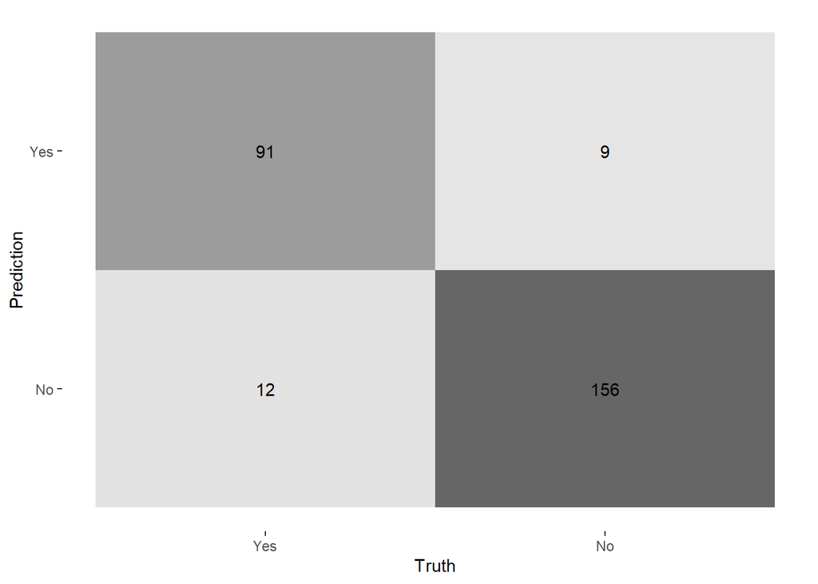

```r
knn_test %>%
  conf_mat(truth = survived, estimate = .pred_class) %>%
  autoplot(type = "heatmap")
```

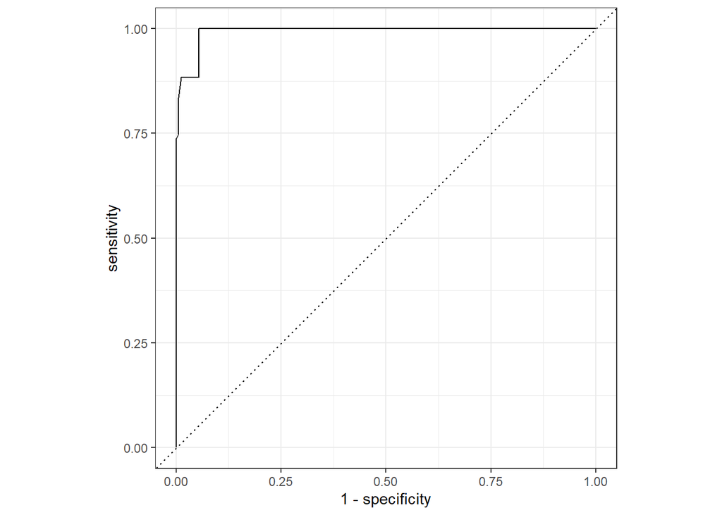

```r
knn_test %>%
  roc_curve(survived, .pred_Yes) %>%
  autoplot()
```

```r
titanic_kbb_roc %>%
  roc_auc(survived, .pred_Yes)
```

```
## # A tibble: 1 × 3
##   .metric .estimator .estimate
##   <chr>   <chr>          <dbl>
## 1 roc_auc binary         0.989
```

```r
knn_test %>%
  roc_auc(survived, .pred_Yes)
```

```
## # A tibble: 1 × 3
##   .metric .estimator .estimate
##   <chr>   <chr>          <dbl>
## 1 roc_auc binary         0.993
```

My best model which is Knn model perform better on the testing dataset. I think the reason might be that the testing dataset has fewer observations than the training dataset. Also, I might just be lucky on choosing my random seed.